# 7-Employment_migration

## 0.1 General Instructions

1. This code computes the preliminary mobility matrices for each state and sector for years 2015-2018.
2. This code computes the employment level for each state and sector in year 2018.
3. This code computes the employment distribution by sector for each country and each year 2015-2018. It also applies proportionality to $L_{2018}$ of step 2 so that the matrix is consistent with WIOD.
4. This code computes the final (all regions) employment distribution, L, for 2015-2018 and the final mobility matrices 2015-2018.
5. This code recreates CDP’s Table I (percentages of moving workers’ categories) and produces an histogram for the diagonal values of mobility matrix 2018.

## 0.2 Input files

1. `0-Raw_Data/BLS/state_employ.xlsx`
2. `0-Raw_Data/sectors_naics.csv`
3. `0-Raw_Data/sectors_census_1990.csv`
4. `0-Raw_Data/sectors_census_2003.csv`
5. `0-Raw_Data/FIPS/states_fips_num.xlsx`
6. `0-Raw_Data/ACS/`yr`/ss`yr``state`.csv`
7. `0-Raw_Data/CPS/`month``yr`pub_.txt`
8. `0-Raw_Data/sectors_WIOD_SEA_final.csv`
9. `0-Raw_Data/WIOD/Socio_Economic_Accounts.xlsx`
10. `0-Raw_Data/LFP_WB.csv`
11. `0-Raw_Data/ILO/EMP_2EMP_SEX_ECO_NB_A_EN.xlsx`

## 0.4 Importing general datasets to R

```r
#General
`%notin%` <- Negate(`%in%`)

regions <- read.csv("0-Raw_Data/regions.csv")
c_names <- regions %>% filter(status == "country")
c_names <- c_names$region

s_names <- regions %>% filter(status == "state")
s_names <- s_names$region

n_s <- length(s_names)
n_c <- length(c_names) -1

#sector reclassification table (NAICS to final)
sectors_naics_final <- read.csv("0-Raw_Data/sectors_naics.csv", fileEncoding="UTF-8-BOM")
sectors_naics_final <- sectors_naics_final %>%
  dplyr::rename(naics = NAICS) %>%
  select(final_sector, naics) %>%
  mutate(naics = as.character(naics)) %>%
  distinct(final_sector, naics)


#sectors (CENSUS 2003 to naics)
sectors_census2003_naics <- read.csv(paste("0-Raw_Data/sectors_census_2003.csv", sep=""), header = TRUE, sep = ",", dec = ".")
sectors_census2003_naics <- sectors_census2003_naics %>%
  mutate(naics = as.character(naics)) %>%
  distinct(census_2003, .keep_all = TRUE)

#sectors (CENSUS 2003 to final)
sectors_census2003_final <- sectors_census2003_naics %>%
  left_join(sectors_naics_final, by=c('naics'='naics')) %>% #NAICS to final sector
  filter(is.na(final_sector) == FALSE) %>%
  mutate(census_2003 = as.character(census_2003)) %>%
  select(census_2003, final_sector)

#state codes
states_fips <- read_excel("0-Raw_Data/Fips/states_fips_num.xlsx", range = "A1:D53")
states_fips <- states_fips %>% select(st_fips, st_num, st_name)


#employment by year, sector, and country WIOD
SEA <- read_excel("0-Raw_Data/WIOD/Socio_Economic_Accounts.xlsx", sheet = "DATA")
```

[output not shown]

[output cut: 3305 more lines]

[output not shown]

```r
colnames(SEA) <- c("country", "variable", "description", "code", "2000", "2001", "2002", "2003", "2004", "2005", "2006", "2007", "2008", "2009", "2010", "2011", "2012", "2013", "2014")

#sectors WIOD SEA to final
sectors_WIOD_SEA_final <- read.csv(paste("0-Raw_Data/sectors_WIOD_SEA_final.csv", sep=""), header = TRUE, sep = ",", dec = ".")
sectors_WIOD_SEA_final <- sectors_WIOD_SEA_final %>% select(-code)
colnames(sectors_WIOD_SEA_final) <- c("description", "final_sector")


#Labor force participation rate (World Bank)
LFP_WB <- read.csv("0-Raw_Data/LFP_WB.csv")
LFP_WB <- LFP_WB %>%
  select(Country.Code, X2014, X2015, X2016, X2017, X2018) %>%
  dplyr::rename(country = Country.Code)
LFP_WB <- reshape2::melt(LFP_WB, id.vars=c("country"), variable.name="year", value.name = "lfp_rate")
LFP_WB <- LFP_WB %>%
  mutate(year = as.numeric(gsub("X", "", year))) %>%
  filter(is.na(lfp_rate) == FALSE) %>%
  mutate(country = ifelse(country == "ROM", "ROU", country)) %>%
  mutate(country = ifelse(country == "WLD", "RoW", country)) %>%
  filter(country %in% c_names)

temp_LFP_2014 <- c("TWN", 2014, 58.5) #TRADING ECONOMICS
temp_LFP_2015 <- c("TWN", 2015, 58.6) #TRADING ECONOMICS
temp_LFP_2016 <- c("TWN", 2016, 58.7) #TRADING ECONOMICS
temp_LFP_2017 <- c("TWN", 2017, 58.8) #TRADING ECONOMICS
temp_LFP_2018 <- c("TWN", 2018, 58.9) #TRADING ECONOMICS

LFP_WB <- rbind(LFP_WB, temp_LFP_2014, temp_LFP_2015, temp_LFP_2016, temp_LFP_2017, temp_LFP_2018)
LFP_WB$year <- as.numeric(LFP_WB$year)
LFP_WB$lfp_rate <- as.numeric(LFP_WB$lfp_rate)


all_country_names=c("Aruba", "Afghanistan", "Angola", "Anguilla", "Aland Islands", "Albania", "Andorra", "United Arab Emirates", "Argentina", "Armenia", "American_Samoa", "Antarctica", "French Southern Territories", "Antigua and Barbuda", "Australia", "Austria", "Azerbaijan", "Burundi", "Belgium", "Benin", "Bonaire, Sint Eustatius and Saba", "Burkina_Faso", "Bangladesh", "Bulgaria", "Bahrain", "Bahamas", "Bosnia and Herzegovina", "Saint Barthelemy", "Belarus", "Belize", "Bermuda", "Bolivia", "Brazil", "Barbados", "Brunei Darussalam", "Bhutan", "Bouvet Island", "Botswana", "Central African Republic", "Canada", "Cocos Islands", "Switzerland", "Chile", "China", "Cote d Ivoire", "Cameroon", "Democratic Republic of the Congo", "Congo", "Cook Islands", "Colombia", "Comoros", "Cabo Verde", "Costa Rica", "Cuba", "Curacao", "Christmas Island", "Cayman Islands", "Cyprus", "Czechia", "Germany", "Djibouti", "Dominica", "Denmark", "Dominican Republic", "Algeria", "Ecuador", "Egypt", "Eritrea", "Western Sahara", "Spain", "Estonia", "Ethiopia", "Finland", "Fiji", "Falkland Islands", "France", "Faroe Islands", "Micronesia", "Gabon", "United Kingdom", "Georgia", "Guernsey", "Ghana", "Gibraltar", "Guinea", "Guadeloupe", "Gambia", "Guinea-Bissau", "Equatorial Guinea", "Greece", "Grenada", "Greenland", "Guatemala", "French Guiana", "Guam", "Guyana", "Hong Kong", "Heard Island and McDonald Islands", "Honduras", "Croatia", "Haiti", "Hungary", "Indonesia", "Isle of Man", "India", "British Indian Ocean Territory", "Ireland", "Iran", "Iraq", "Iceland", "Israel", "Italy", "Jamaica", "Jersey", "Jordan", "Japan", "Kazakhstan", "Kenya", "Kyrgyzstan", "Cambodia", "Kiribati", "Saint Kitts and Nevis", "Korea, Republic of", "Kuwait", "Laos", "Lebanon", "Liberia", "Libya", "Saint Lucia", "Liechtenstein", "Sri Lanka", "Lesotho", "Lithuania", "Luxembourg", "Latvia", "Macao", "Saint Martin", "Morocco", "Monaco", "Moldova", "Madagascar", "Maldives", "Mexico", "Marshall Islands", "North Macedonia", "Mali", "Malta", "Myanmar", "Montenegro", "Mongolia", "Northern Mariana Islands", "Mozambique", "Mauritania", "Montserrat", "Martinique", "Mauritius", "Malawi", "Malaysia", "Mayotte", "Namibia", "New Caledonia", "Niger", "Norfolk Island", "Nigeria", "Nicaragua", "Niue", "Netherlands", "Norway", "Nepal", "Nauru", "New Zealand", "Oman", "Pakistan", "Panama", "Pitcairn", "Peru", "Philippines", "Palau", "Papua New Guinea", "Poland", "Puerto Rico", "North Korea", "Portugal", "Paraguay", "Palestine", "French Polynesia", "Qatar", "Reunion", "Romania", "Russian Federation", "Rwanda", "Saudi Arabia", "Sudan", "Senegal", "Singapore", "South Georgia and the South Sandwich Islands", "Saint Helena, Ascension and Tristan da Cunha", "Svalbard and Jan Mayen", "Solomon Islands", "Sierra Leone", "El Salvador", "San Marino", "Somalia", "Saint Pierre and Miquelon", "Serbia", "South Sudan", "Sao Tome and Principe", "Suriname", "Slovakia", "Slovenia", "Sweden", "Eswatini", "Sint Maarten", "Seychelles", "Syria", "Turks and Caicos Islands", "Chad", "Togo", "Thailand", "Tajikistan", "Tokelau", "Turkmenistan", "Timor-Leste", "Tonga", "Trinidad and Tobago", "Tunisia", "Turkey", "Tuvalu", "Taiwan, China", "Tanzania", "Uganda", "Ukraine", "United States Minor Outlying Islands", "Uruguay", "United States", "Uzbekistan", "Holy See", "Saint Vincent and the Grenadines", "Venezuela", "British Virgin Islands", "American Virgin Islands", "Vietnam", "Vanuatu", "Wallis and Futuna", "Samoa", "Yemen", "South Africa", "Zambia", "Zimbabwe")

all_country_codes=c("ABW", "AFG", "AGO", "AIA", "ALA", "ALB", "AND", "ARE", "ARG", "ARM", "ASM", "ATA", "ATF", "ATG", "AUS", "AUT", "AZE", "BDI", "BEL", "BEN", "BES", "BFA", "BGD", "BGR", "BHR", "BHS", "BIH", "BLM", "BLR", "BLZ", "BMU", "BOL", "BRA", "BRB", "BRN", "BTN", "BVT", "BWA", "CAF", "CAN", "CCK", "CHE", "CHL", "CHN", "CIV", "CMR", "COD", "COG", "COK", "COL", "COM", "CPV", "CRI", "CUB", "CUW", "CXR", "CYM", "CYP", "CZE", "DEU", "DJI", "DMA", "DNK", "DOM", "DZA", "ECU", "EGY", "ERI", "ESH", "ESP", "EST", "ETH", "FIN", "FJI", "FLK", "FRA", "FRO", "FSM", "GAB", "GBR", "GEO", "GGY", "GHA", "GIB", "GIN", "GLP", "GMB", "GNB", "GNQ", "GRC", "GRD", "GRL", "GTM", "GUF", "GUM", "GUY", "HKG", "HMD", "HND", "HRV", "HTI", "HUN", "IDN", "IMN", "IND", "IOT", "IRL", "IRN", "IRQ", "ISL", "ISR", "ITA", "JAM", "JEY", "JOR", "JPN", "KAZ", "KEN", "KGZ", "KHM", "KIR", "KNA", "KOR", "KWT", "LAO", "LBN", "LBR", "LBY", "LCA", "LIE", "LKA", "LSO", "LTU", "LUX", "LVA", "MAC", "MAF", "MAR", "MCO", "MDA", "MDG", "MDV", "MEX", "MHL", "MKD", "MLI", "MLT", "MMR", "MNE", "MNG", "MNP", "MOZ", "MRT", "MSR", "MTQ", "MUS", "MWI", "MYS", "MYT", "NAM", "NCL", "NER", "NFK", "NGA", "NIC", "NIU", "NLD", "NOR", "NPL", "NRU", "NZL", "OMN", "PAK", "PAN", "PCN", "PER", "PHL", "PLW", "PNG", "POL", "PRI", "PRK", "PRT", "PRY", "PSE", "PYF", "QAT", "REU", "ROU", "RUS", "RWA", "SAU", "SDN", "SEN", "SGP", "SGS", "SHN", "SJM", "SLB", "SLE", "SLV", "SMR", "SOM", "SPM", "SRB", "SSD", "STP", "SUR", "SVK", "SVN", "SWE", "SWZ", "SXM", "SYC", "SYR", "TCA", "TCD", "TGO", "THA", "TJK", "TKL", "TKM", "TLS", "TON", "TTO", "TUN", "TUR", "TUV", "TWN", "TZA", "UGA", "UKR", "UMI", "URY", "USA", "UZB", "VAT", "VCT", "VEN", "VGB", "VIR", "VNM", "VUT", "WLF", "WSM", "YEM", "ZAF", "ZMB", "ZWE")

codes <- data.frame(cbind(all_country_names, all_country_codes))
```

#Task 1

```r
#Mobility matrices (mu)

#ACS: state to state-sector movements
yr_list <- c("15", "16", "17", "18", "19")
st_list <- c("al", "ak", "az", "ar", "ca", "co", "ct", "de", "fl", "ga", "hi", "id", "il", "in", "ia", "ks", "ky", "la", "me", "md", "ma", "mi", "mn", "ms", "mo", "mt", "ne", "nv", "nh", "nj", "nm", "ny", "nc", "nd", "oh", "ok", "or", "pa", "ri", "sc", "sd", "tn", "tx", "ut", "vt", "va", "wa", "wv", "wi", "wy")
st_list_num <- c("01", "02", "04", "05", "06", "08", "09", "10", "12", "13", "15", "16", "17", "18", "19", "20", "21", "22", "23", "24", "25", "26", "27", "28", "29", "30", "31", "32", "33", "34", "35", "36", "37", "38", "39", "40", "41", "42", "44", "45", "46", "47", "48", "49", "50", "51", "53", "54", "55", "56")



#loading PUMS ACS
acs <- c()
yr_c <- 2015
for (yr in yr_list) {
print(yr)
c <- 1
for (st in 1:50) {
#print(st)
if (yr_c <= 2016){ACS_PUMS <- read_csv(paste("0-Raw_Data/ACS/20", yr,"/ss", yr,"p", st_list[st],".csv", sep=""), col_types = cols())}
if (yr_c >= 2017){ACS_PUMS <- read_csv(paste("0-Raw_Data/ACS/20", yr,"/psam_p", st_list_num[st],".csv", sep=""), col_types = cols())}
ACS_PUMS$year <- yr_c
ACS_PUMS <- ACS_PUMS %>%
  select(year, AGEP, POWSP, MIGSP, ESR, NAICSP, PWGTP) %>%
  mutate(AGEP = as.numeric(AGEP),
         POWSP = as.numeric(POWSP),
         MIGSP = as.numeric(MIGSP),
         ESR = as.numeric(ESR),
         PWGTP = as.numeric(PWGTP)) %>%
  filter( is.na(AGEP) == TRUE  | (AGEP >= 25 & AGEP <=65)) %>% # age
  filter( is.na(ESR) == FALSE & (ESR==1 |ESR==2 | ESR==3 | ESR==6)) %>% #employ status
  mutate(ESR = as.numeric( recode( as.character(ESR), '6' ="0", '3' ="0", '1' = "1", '2' = "1"))) %>%
  filter( is.na(POWSP) == TRUE | (is.na(POWSP) == FALSE & POWSP != 11 & POWSP <= 56)) %>%
  left_join(states_fips, by=c('POWSP' = 'st_fips')) %>%
  filter( is.na(st_num) == TRUE  | (is.na(st_num) == FALSE & st_num == c)) %>% # workplace (state)
  select(-st_name, -POWSP, -st_num) %>%
  mutate(state_dest = s_names[c]) %>%
  filter( is.na(MIGSP) == TRUE | (is.na(MIGSP) == FALSE & MIGSP != 11 & MIGSP <= 56)) %>%
  left_join(states_fips, by=c('MIGSP' = 'st_fips')) %>% #lived 1 yr ago
  select(-MIGSP, -st_num, -AGEP) %>%
  dplyr::rename(state_ori = st_name, employ_status = ESR) %>%
  mutate(state_ori = ifelse(is.na(state_ori) == TRUE, s_names[c], state_ori)) %>% # no MIG
  dplyr::rename(naics = NAICSP) %>%
  mutate(naics = substr(naics, start=1, stop=3)) %>%
  mutate(naics = ifelse(employ_status == 0, NA, naics)) %>%
  filter((employ_status == 0 & is.na(naics) == TRUE)|(employ_status == 1 & is.na(naics) == FALSE)) %>%
  mutate(naics = ifelse(naics == "23", "230", naics)) %>%
  mutate(naics = ifelse(naics == "31M", "313", naics)) %>%
  mutate(naics = ifelse(naics == "4MS", "423", naics)) %>%
  left_join(sectors_naics_final, by=c('naics'='naics')) %>% #NAICS to final sector
  dplyr::rename(sector_dest = final_sector) %>%
  filter(is.na(sector_dest) == FALSE) %>%
  select(-naics, -employ_status)

#counting by state and sector, origin and dest
ACS_PUMS <- ACS_PUMS %>%
  group_by(year, sector_dest, state_dest, state_ori) %>%
  mutate(n = sum(PWGTP)) %>% #weights (how many the obs represents)
  ungroup() %>%
  distinct(year, sector_dest, state_dest, state_ori, .keep_all = TRUE) %>%
  select(-PWGTP)

#adding missing combinations state_sector_dest-state_ori
add <- c()
for (sec in 0:14) {
temp <- data.frame(s_names)
temp <- temp %>%
  dplyr::rename(state_ori = s_names) %>%
  mutate(state_dest = s_names[c], year = yr_c, sector_dest = sec, n = 0)
add <- rbind(add, temp)
}
ACS_PUMS <- rbind(ACS_PUMS, add)
rm(add, temp)
ACS_PUMS  <- ACS_PUMS %>%
  group_by(year, sector_dest, state_dest, state_ori) %>%
  mutate(n_acs = max(n)) %>%
  ungroup() %>%
  select(-n) %>%
  distinct(year, sector_dest, state_dest, state_ori, .keep_all = TRUE) %>%
  arrange(year, sector_dest, state_dest, state_ori)

acs <- rbind(acs, ACS_PUMS)

c <- c + 1
}
yr_c <- yr_c + 1
}
```

```
[1] "15"
[1] "16"
[1] "17"
[1] "18"
```

[output not shown]

[output cut: 314 more lines]

[output not shown]

```
[1] "19"
```

[output not shown]

[output cut: 314 more lines]

[output not shown]

```r
#mu matrices named after base year
acs <- acs %>%
  mutate(year = year - 1)
rm(ACS_PUMS)

write.table(acs, file = paste("1-Intermediate_Processed_Data//acs_temp.csv", sep=""), sep = ",", row.names = FALSE)

acs <- read.csv(paste("1-Intermediate_Processed_Data//acs_temp.csv", sep=""), header = TRUE, sep = ",", dec = ".")


#rolling basis
final_base <- c()
for (yr in 2014:2018) {
temp <- acs %>%
  filter(year >= yr & year <= yr + 2) %>%
  mutate(year = yr)
final_base <- rbind(final_base, temp)
}
acs <- final_base
#counting by state and sector, origin and dest
acs <- acs %>%
  group_by(year, sector_dest, state_dest, state_ori) %>%
  mutate(n_acs = sum(n_acs)) %>%
  ungroup() %>%
  distinct(year, sector_dest, state_dest, state_ori, .keep_all = TRUE)



##check
acs <- acs %>%
  mutate(diag = ifelse(state_ori == state_dest, 1, 0)) %>%
  group_by(state_ori, state_dest, sector_dest) %>%
  mutate(n_acs_mean = mean(n_acs)) %>%
  ungroup() %>%
  mutate(n_acs = ifelse(diag == 1 & n_acs == 0, n_acs_mean, n_acs)) %>%
  select(-n_acs_mean, -diag)

acs <- acs %>%
  mutate(n_acs_temp = ifelse(state_ori==state_dest, n_acs, 0)) %>%
  group_by(year, state_ori, sector_dest) %>%
  mutate(n_acs_temp = max(n_acs_temp), mean_n_acs = mean(n_acs)) %>%
  ungroup() %>%
  mutate(n_acs = ifelse(n_acs_temp<n_acs, mean_n_acs, n_acs)) %>%
  select(-n_acs_temp, -mean_n_acs)

acs <- acs %>%
  mutate(n_acs_temp = ifelse(state_ori==state_dest, n_acs, 0)) %>%
  group_by(year, state_dest, sector_dest) %>%
  mutate(n_acs_temp = max(n_acs_temp),mean_n_acs = mean(n_acs)) %>%
  ungroup() %>%
  mutate(n_acs = ifelse(n_acs_temp<n_acs, mean_n_acs, n_acs)) %>%
  select(-n_acs_temp, -mean_n_acs)


write.table(acs, file = paste("1-Intermediate_Processed_Data//acs.csv", sep=""), sep = ",", row.names = FALSE)
```

```r
#Mobility matrices (mu)

#CPS: sector-sector within state movements
mn_list <- c("jan", "feb", "mar", "apr", "may", "jun", "jul", "aug", "sep", "oct", "nov", "dec")
yr_list <- c("13","14", "15", "16", "17", "18", "19", "20")

#loading PUMS CPS
cps_list <- vector("list", length = length(mn_list)*length(yr_list))
p <- 1
for (yr in yr_list){
print(yr)
for (mn in mn_list){
CPS_PUMS <- read_csv(paste("0-Raw_Data/CPS/", mn, yr,"pub_.txt", sep=""), col_names = FALSE, col_types = cols())
CPS_PUMS$year <- yr
CPS_PUMS$month <- mn


#creating variables
CPS_PUMS <- CPS_PUMS %>%
  mutate(year = as.numeric(year)) %>%
  mutate(year = ifelse( (year!=99 & year!=98 & year!=97), 2000 + year, 1900+year)) %>%
  mutate(len = nchar(X1)) %>% #len matches data dictionary
  mutate(person_weight_1 = as.numeric(substr(X1, start=846, stop=855))) %>% #weight final
  mutate(person_weight_2 = as.numeric(substr(X1, start=593, stop=602))) %>% #weight longitude
  mutate(inter_num = as.numeric(substr(X1, start=63, stop=64))) %>% #interview number (1-8)
  mutate(H_ID_1 = substr(X1, start=1, stop=15)) %>% #household ID
  mutate(H_ID_2 = substr(X1, start=71, stop=75)) %>%
  mutate(H_ID = paste(H_ID_1, H_ID_2, sep="_")) %>%
  select(-H_ID_1, -H_ID_2) %>%
  mutate(age = as.numeric(substr(X1, start=122, stop=123))) %>% #age
  filter(age >=25 & age <=65) %>%
  mutate(gender = as.numeric(substr(X1, start=129, stop=130))) %>% #male: 1; female: 2
  arrange(year, month, H_ID, -age) %>%
  group_by(year, month, H_ID) %>%
  mutate(P_ID = 1:n()) %>%
  ungroup() %>%
  mutate(employ_status = as.numeric(substr(X1, start=180, stop=181))) %>% #employ status
  filter( is.na(employ_status)==FALSE & ((employ_status>=1 & employ_status<=6)|employ_status==7)) %>%
  mutate(employ_status = as.numeric( recode( as.character(employ_status), '6' ="0", '5' ="0", '7' ="0", '4' ="0", '3' ="0", '2' = "1", '1' = "1"))) %>%
  mutate(st_fips = as.numeric(substr(X1, start=93, stop=94))) %>% #state
  filter( is.na(st_fips) == FALSE & (st_fips != 11 & st_fips <= 56)) %>%
  left_join(states_fips, by=c('st_fips' = 'st_fips')) %>%
  select(-st_fips) %>%
  mutate(census_sec = substr(X1, start = 856, stop=858)) %>% #census_sec
  mutate(census_sec = ifelse(employ_status == 0, NA, census_sec)) %>%
  filter((employ_status == 0 & is.na(census_sec) == TRUE)|(employ_status == 1 & is.na(census_sec) == FALSE)) %>%
  mutate(census_sec = gsub(" ", "", census_sec)) %>%
  select(-X1)

cps_list[[p]] <- CPS_PUMS
rm(CPS_PUMS)
print(paste0(yr, ",", mn))

p <- p + 1
}
}
```

```
[1] "13"
[1] "13,jan"
[1] "13,feb"
[1] "13,mar"
[1] "13,apr"
[1] "13,may"
[1] "13,jun"
[1] "13,jul"
[1] "13,aug"
[1] "13,sep"
[1] "13,oct"
[1] "13,nov"
[1] "13,dec"
[1] "14"
[1] "14,jan"
```

[output cut: 89 more lines]

```r
cps <- rbindlist(cps_list)
cps <- cps %>%
  arrange(year, month, H_ID, -age)
rm(cps_list)

#sectors

cps <- cps %>%
  filter(year >= 2003) %>%
  left_join(sectors_census2003_final, by=c('census_sec'='census_2003')) %>% #census_sec to final sector
  dplyr::rename(sector = final_sector) %>%
  filter(is.na(sector) == FALSE) %>%
  select(-census_sec, -len, -employ_status, -st_num)

write.table(cps, file = paste("1-Intermediate_Processed_Data//cps_1.csv", sep=""), sep = ",", row.names = FALSE)

cps <- read.csv(paste("1-Intermediate_Processed_Data//cps_1.csv", sep=""), header = TRUE, sep = ",", dec = ".")
acs <- read.csv(paste("1-Intermediate_Processed_Data//acs.csv", sep=""), header = TRUE, sep = ",", dec = ".")
mn_list <- c("jan", "feb", "mar", "apr", "may", "jun", "jul", "aug", "sep", "oct", "nov", "dec")

#dropping households with incomplete interviews (in 2013 and 2020) #annual matching
a <- dim(cps)[1]
no_match <- cps %>%
  group_by(H_ID) %>%
  filter( min(inter_num) > 4 | max(inter_num) < 5 ) %>%
  filter(year == 2013 | year == 2020) %>%
  ungroup()
b <- dim(no_match)[1]
cps <- cps %>%
  group_by(H_ID) %>%
  filter( min(inter_num) <=4 & max(inter_num) >=5 ) %>%
  ungroup()
c <- dim(cps)[1]

#household matching rate
print(c*100/(a-b))
```

```
[1] 84.81641
```

```r
rm(no_match)


#matching persons via same month in consecutive years
base <- c()
for (yr in 2014:2020) {
for (mn in mn_list) {
#print(yr)
#print(mn)
temp_cps <- cps %>%
  filter(month == mn & ( (year == yr & inter_num==5) | (year == yr-1 & inter_num==1) ))

a <- dim(temp_cps)[1]
temp_cps <- temp_cps %>%
  group_by(H_ID, P_ID) %>%
  filter( abs(max(age)-min(age)) <= 1  & max(gender) == min(gender)) %>%
  ungroup()
b <- dim(temp_cps)[1]
#person matching rate
print(b*100/a)
info_present <- temp_cps %>%
  filter(year == yr) %>%
  dplyr::rename(sector_dest = sector, state_dest = st_name)
info_past <- temp_cps %>%
  filter(year == yr-1) %>%
  select(-age, -year, -month, -gender, -inter_num, -person_weight_1, -person_weight_2) %>%
  dplyr::rename(sector_ori = sector, state_ori = st_name)
temp <- full_join(info_present, info_past, by=c("H_ID", "P_ID"))
temp <- temp %>%
  filter(is.na(state_ori) == FALSE & is.na(state_dest) == FALSE) %>% #only matches
  distinct(H_ID, P_ID, .keep_all = TRUE)
base <- rbind(base, temp)
}
}
```

```
[1] 85.93435
[1] 86.45779
[1] 85.74649
[1] 85.85024
[1] 85.3864
[1] 86.10169
[1] 86.36068
[1] 86.10654
[1] 87.35299
[1] 87.22854
[1] 86.18243
[1] 87.02163
[1] 85.35161
[1] 87.61281
[1] 86.01206
```

[output cut: 69 more lines]

```r
#rolling basis
final_base <- c()
for (yr in 2015:2019) {
temp <- base %>%
  filter(year >= yr - 2 & year <= yr + 2) %>%
  mutate(year = yr)
final_base <- rbind(final_base, temp)
}
base <- final_base %>% mutate(year = year - 1)

#counting sector-sector within state movements
base <- base %>%
  select(-month, -H_ID, -P_ID, -gender, -inter_num) %>%
  filter(person_weight_1!= -1) %>%
  group_by(year, state_ori, sector_ori, state_dest, sector_dest) %>%
  mutate(n_cps = sum(person_weight_1/(10000))) %>%
  ungroup() %>%
  distinct(year, state_ori, sector_ori, state_dest, sector_dest, .keep_all = TRUE) %>%
  select(year, state_ori, sector_ori, state_dest, sector_dest, n_cps)


#adding missing combinations
add <- c()
for (sec_ori in 0:14) {
#print(sec_ori)
temp <- acs %>%
  dplyr::rename(n_cps = n_acs) %>%
  mutate(sector_ori = sec_ori, n_cps = 0)
add <- rbind(add, temp)
}
add <- add %>% select(year, state_ori, sector_ori, state_dest, sector_dest, everything())
base <- rbind(base, add)
rm(add, temp, info_past, info_present, temp_cps)
cps  <- base %>%
  group_by(year, state_ori, sector_ori, state_dest, sector_dest) %>%
  mutate(n_cps = max(n_cps)) %>%
  ungroup() %>%
  distinct(year, state_ori, sector_ori, state_dest, sector_dest, .keep_all = TRUE)
rm(base, final_base)



#replacing 0 in diag for min non-zero
temp <- cps %>%
  mutate(diag = ifelse(sector_ori == sector_dest & state_ori == state_dest, 1, 0)) %>%
  filter(diag == 1 & n_cps != 0) %>%
  group_by(year, diag) %>%
  mutate(min_diag = min(n_cps)) %>%
  ungroup() %>%
  distinct(year, .keep_all = TRUE) %>%
  select(year, min_diag)
cps <- cps %>%
  left_join(temp, by=c("year"="year")) %>%
  mutate(diag = ifelse(sector_ori == sector_dest & state_ori == state_dest, 1, 0)) %>%
  mutate(n_cps = ifelse(diag == 1 & n_cps == 0 , min_diag, n_cps)) %>%
  select(-min_diag, -diag)
rm(temp)


#filling missing matrix sections as CDP
cps <- cps %>%
  mutate(n_master = ifelse(state_ori == state_dest, n_cps, 0)) %>%
  select(-n_cps) %>%
  group_by(year, state_dest, sector_dest, sector_ori) %>%
  mutate(n_cps = max(n_master)) %>%
  ungroup() %>%
  select(-n_master) %>%
  arrange(year, state_dest, sector_dest, state_ori, sector_ori)


write.table(cps, file = paste("1-Intermediate_Processed_Data//cps_2.csv", sep=""), sep = ",", row.names = FALSE)
```

```r
#loading intermediate CPS
cps <- read.csv(paste("1-Intermediate_Processed_Data//cps_2.csv", sep=""), header = TRUE, sep = ",", dec = ".")

#loading intermediate ACS
acs <- read.csv(paste("1-Intermediate_Processed_Data//acs.csv", sep=""), header = TRUE, sep = ",", dec = ".")


#Mobility matrices

#disaggregating ACS data using CPS sector_ori info and computation of mobility share
#origin in rows and destination in columns
#col shares sum to 1

acs <- acs %>%
  group_by(year, state_ori, state_dest) %>%
  mutate(n_acs = sum(n_acs)) %>%
  ungroup() %>%
  distinct(year, state_ori, state_dest, .keep_all = TRUE) %>%
  select(-sector_dest)

#adjusting x's to y's
mobility <- cps %>%
  left_join(acs, by=c('year' = 'year', 'state_dest' = 'state_dest', 'state_ori' = 'state_ori')) %>%
  group_by(year, state_dest, state_ori) %>%
  mutate(tot_n_cps_accros_sec = sum(n_cps)) %>%
  ungroup() %>%
  mutate(n_cps_adj = n_cps/tot_n_cps_accros_sec) %>%
  mutate(n_cps_adj = ifelse(is.na(n_cps_adj) == TRUE, 0, n_cps_adj)) %>%
  mutate(n_cps_adj = n_cps_adj*n_acs) %>%
  select(-tot_n_cps_accros_sec, -n_cps, -n_acs)


#x's adjusted by y to shares
mobility <- mobility %>%
  group_by(year, state_dest, sector_dest) %>%
  mutate(tot_n_cps_accros_ori = sum(n_cps_adj)) %>%
  ungroup() %>%
  mutate(rel = n_cps_adj/tot_n_cps_accros_ori) %>%
  mutate(rel = ifelse(is.na(rel)==TRUE & state_dest==state_ori & sector_dest== sector_ori, 1, rel)) %>%
  mutate(rel = ifelse(is.na(rel)==TRUE, 0, rel)) %>%
  distinct(year, state_dest, state_ori, sector_dest, sector_ori, .keep_all = TRUE) %>%
  select(year, state_dest, state_ori, sector_dest, sector_ori, rel) %>%
  arrange(year, state_ori, sector_ori, state_dest, sector_dest)

mu_all <- c()
epsilon <- 0.001
for (yr in 2015:2017) {
final <- mobility %>%
  filter(year == yr)
#taking out 0's in diagonal and renormalizing so that sum(prob)==1
temp <- final %>%
  mutate(diag = ifelse(sector_ori == sector_dest & state_ori == state_dest, 1, 0)) %>%
  filter(diag == 1 & rel != 0) %>%
  group_by(diag) %>%
  mutate(min_diag = min(rel)) %>%
  ungroup()
a <- temp$min_diag[1]
final <- final %>%
  mutate(diag = ifelse(sector_ori == sector_dest & state_ori == state_dest, 1, 0)) %>%
  mutate(rel = ifelse(diag == 1 & rel == 0 , a, rel)) %>%
  group_by(year, state_dest, sector_dest) %>% #renormalizing
  mutate(tot_rel = sum(rel)) %>%
  ungroup() %>%
  mutate(rel = rel/tot_rel) %>%
  select(-diag, -tot_rel)
mu_all <- rbind(mu_all, final)

final <- final %>%
  mutate(sector_dest = recode(as.character(sector_dest), '0' ="00", '1' ="01", '2' ="02", '3' ="03", '4' ="04", '5' ="05", '6' ="06", '7' ="07", '8' ="08", '9' ="09" )) %>%
  mutate(state_dest_sector_dest = paste(state_dest, sector_dest, sep="_")) %>%
  select(-state_dest, -sector_dest)

final <- spread(final, state_dest_sector_dest, rel, fill = NA, convert = TRUE,  drop = TRUE, sep = NULL)

#check
check <- final %>% select(-year, -state_ori, -sector_ori)
if(sum(abs(as.matrix(colSums(check)) - matrix(1, dim(check)[1], 1))) > epsilon)
  stop(paste("mobility shares do not add to 1,", yr))
write_xlsx(final, paste("1-Intermediate_Processed_Data//mu_", yr, "_col.xlsx", sep=""))
}


rm(acs, cps, mobility, check, final, mu_all, temp)
```

```r
#loading intermediate CPS
cps <- read.csv(paste("1-Intermediate_Processed_Data//cps_2.csv", sep=""), header = TRUE, sep = ",", dec = ".")

#loading intermediate ACS
acs <- read.csv(paste("1-Intermediate_Processed_Data//acs.csv", sep=""), header = TRUE, sep = ",", dec = ".")


#Mobility matrices

#disaggregating ACS data using CPS sector_ori info and computation of mobility share
#origin in rows and destination in columns
#row shares sum to 1

acs <- acs %>%
  group_by(year, state_ori, state_dest) %>%
  mutate(n_acs = sum(n_acs)) %>%
  ungroup() %>%
  distinct(year, state_ori, state_dest, .keep_all = TRUE) %>%
  select(-sector_dest)

#adjusting x's to y's
mobility <- cps %>%
  left_join(acs, by=c('year' = 'year', 'state_dest' = 'state_dest', 'state_ori' = 'state_ori')) %>%
  group_by(year, state_dest, state_ori) %>%
  mutate(tot_n_cps_accros_sec = sum(n_cps)) %>%
  ungroup() %>%
  mutate(n_cps_adj = n_cps/tot_n_cps_accros_sec) %>%
  mutate(n_cps_adj = ifelse(is.na(n_cps_adj) == TRUE, 0, n_cps_adj)) %>%
  mutate(n_cps_adj = n_cps_adj*n_acs) %>%
  select(-tot_n_cps_accros_sec, -n_cps, -n_acs)


#x's adjusted by y to shares
mobility <- mobility %>%
  group_by(year, state_ori, sector_ori) %>%
  mutate(tot_n_cps_accros_dest = sum(n_cps_adj)) %>%
  ungroup() %>%
  mutate(rel = n_cps_adj/tot_n_cps_accros_dest) %>%
  mutate(rel = ifelse(is.na(rel)==TRUE & state_dest==state_ori & sector_dest== sector_ori, 1, rel)) %>%
  mutate(rel = ifelse(is.na(rel)==TRUE, 0, rel)) %>%
  distinct(year, state_dest, state_ori, sector_dest, sector_ori, .keep_all = TRUE) %>%
  select(year, state_dest, state_ori, sector_dest, sector_ori, rel) %>%
  arrange(year, state_ori, sector_ori, state_dest, sector_dest)

mu_all <- c()
epsilon <- 0.001
for (yr in 2018:2018) {
final <- mobility %>%
  filter(year == yr)
#taking out 0's in diagonal and renormalizing so that sum(prob)==1
temp <- final %>%
  mutate(diag = ifelse(sector_ori == sector_dest & state_ori == state_dest, 1, 0)) %>%
  filter(diag == 1 & rel != 0) %>%
  group_by(diag) %>%
  mutate(min_diag = min(rel)) %>%
  ungroup()
a <- temp$min_diag[1]
final <- final %>%
  mutate(diag = ifelse(sector_ori == sector_dest & state_ori == state_dest, 1, 0)) %>%
  mutate(rel = ifelse(diag == 1 & rel == 0 , a, rel)) %>%
  group_by(year, state_ori, sector_ori) %>% #renormalizing
  mutate(tot_rel = sum(rel)) %>%
  ungroup() %>%
  mutate(rel = rel/tot_rel) %>%
  select(-diag, -tot_rel)
mu_all <- rbind(mu_all, final)

final <- final %>%
  mutate(sector_dest = recode(as.character(sector_dest), '0' ="00", '1' ="01", '2' ="02", '3' ="03", '4' ="04", '5' ="05", '6' ="06", '7' ="07", '8' ="08", '9' ="09" )) %>%
  mutate(state_dest_sector_dest = paste(state_dest, sector_dest, sep="_")) %>%
  select(-state_dest, -sector_dest)

final <- spread(final, state_dest_sector_dest, rel, fill = NA, convert = TRUE,  drop = TRUE, sep = NULL)

#check
check <- final %>% select(-year, -state_ori, -sector_ori)
if(sum(abs(as.matrix(rowSums(check)) - matrix(1, dim(check)[1], 1))) > epsilon)
  stop(paste("mobility shares do not add to 1,", yr))
write_xlsx(final, paste("2-Final_Data//mu_", yr, ".xlsx", sep=""))
}


rm(acs, cps, mobility, check, final, mu_all, temp)
```

# 1 Task 2

```r
#employment by state
state_pop <- read_excel("0-Raw_Data/BLS/state_employ.xlsx", skip = 7)
state_pop <- state_pop %>%
  filter(FIPS %notin% c("037", "11", "51000")) %>%
  mutate(year = as.numeric(year)) %>%
  filter(year==2018) %>%
  select(state, population) %>% #employed, unemployed and out of labor force
  mutate(state = gsub(" ", "", state)) %>% #taking out spaces
  filter(state %in% s_names) %>%
  mutate(population = population/1000) #to thousands unit (as WIOD)


#computing employment, by sector and state using ACS-2018
acs_L_base <- read.csv(paste("1-Intermediate_Processed_Data//acs.csv", sep=""), header = TRUE, sep = ",", dec = ".")

acs_L_base <- acs_L_base %>%
  filter(year==2017) %>% #destination 2018
  group_by(state_dest, sector_dest) %>%
  mutate(num_employ = sum(n_acs)) %>%
  ungroup() %>%
  distinct(state_dest, sector_dest, .keep_all = TRUE) %>%
  dplyr::rename(state = state_dest, sector = sector_dest) %>%
  select(state, sector, num_employ) %>%
  arrange(state, sector) %>%
  group_by(state) %>%
  mutate(tot = sum(num_employ)) %>%
  ungroup() %>%
  mutate(rel = num_employ/tot) %>%
  left_join(state_pop, by=c('state'='state')) %>%
  mutate(employ = rel*population) %>%
  select(state, sector, employ)

final <- spread(acs_L_base, sector, employ, fill = NA, convert = TRUE,  drop = TRUE, sep = NULL)

#saving
write.table(final, file = paste("1-Intermediate_Processed_Data//L_2018_base.csv", sep=""), sep = ",", row.names = FALSE)


rm(acs_L_base, state_pop, final)
```

# 2 Task 3

```r
SEA_1 <- SEA %>%
  filter(variable == "EMP") %>%
  select(country, description, '2014') %>%
  dplyr::rename(employ='2014')

SEA_1 <- SEA_1 %>%
  mutate(employ = as.numeric(employ), year=2014) %>%
  mutate(employ = ifelse(is.na(employ) == TRUE, 0, employ)) %>%
  left_join(sectors_WIOD_SEA_final, by=c('description'='description')) %>%
  select(-description) %>%
  dplyr::rename(sector = final_sector) %>%
  filter(is.na(sector) == FALSE) %>%
  mutate(country = ifelse(country %notin% c_names, "RoW", country)) %>% #RoW will be fixed soon after
  group_by(year, country, sector) %>%
  mutate(employ = sum(employ)) %>%
  ungroup() %>%
  distinct(year, country, sector, .keep_all = TRUE) %>%
  group_by(country) %>%
  mutate(tot_employ = sum(employ)) %>%
  ungroup() %>%
  mutate(rel = employ/tot_employ) %>%
  select(year, country, sector, rel)

#distributing ILO 2015-2018 country population into sectors using SEA 2014 country-sector
ILO_employ <- read_excel("0-Raw_Data/ILO/EMP_2EMP_SEX_ECO_NB_A_EN.xlsx", skip = 5)
ILO_employ <- ILO_employ %>%
  filter(Sex=="Total" & Time>=2015 & Time<=2018) %>%
  select(Time, 'Reference area', Total) %>%
  dplyr::rename(country = 'Reference area', employ = Total, year=Time) %>%
  left_join(codes, by=c("country"="all_country_names")) %>%
  mutate(all_country_codes = ifelse(country=="World", "RoW", all_country_codes)) %>% #RoW will be fixed soon after
  select(-country) %>%
  dplyr::rename(country = all_country_codes) %>%
  filter(country %in% c_names)


SEA_2 <- c()
for (yr in 2015:2018) {
SEA_temp <- SEA_1 %>%
  mutate(year = yr) %>%
  left_join(ILO_employ, by=c("year"="year", "country"="country")) %>%
  mutate(employ = rel*employ)
SEA_2 <- rbind(SEA_2, SEA_temp)
}
SEA_2 <- SEA_2 %>%
  group_by(year, country) %>%
  mutate(tot_employ = sum(employ)) %>%
  ungroup() %>%
  arrange(year, country, sector) %>%
  select(-rel)


sec_0 <- SEA_2 %>%
  filter(sector == 1) %>%
  mutate(sector = 0) %>%
  left_join(LFP_WB, by=c("year"="year", "country"="country")) %>%
  mutate(lfp_rate = lfp_rate/100) %>%
  mutate(employ = ((1-lfp_rate)/lfp_rate)*tot_employ) %>%
  select(-lfp_rate)

SEA_2 <- rbind(SEA_2, sec_0)
SEA_2 <- SEA_2 %>% select(-tot_employ)
rm(sec_0)

#ROW calibration
bilat <- read_excel("2-Final_Data/bilat_matrix_allyears.xlsx", sheet = "year2018")
bilat <- reshape2::melt(bilat, id.vars=c("importer", "sector"), variable.name="exporter", value.name = "value")
bilat <- bilat %>%
  mutate(exporter = toupper(exporter), sector = sector - 100) %>%
  mutate(exporter = ifelse(exporter == "ROW", "RoW", exporter)) %>%
  mutate(exporter = ifelse(exporter %notin% c_names, "USA", exporter)) %>%
  group_by(exporter, sector) %>%
  mutate(R = sum(value)) %>%
  ungroup() %>%
  group_by(exporter) %>%
  mutate(R_0 = sum(value)) %>% #all sales
  ungroup() %>%
  distinct(exporter, sector, .keep_all = TRUE) %>%
  select(exporter, sector, R, R_0)
bilat_0 <- bilat %>%
  select(exporter, R_0) %>%
  distinct(exporter, .keep_all = TRUE)
bilat <- bilat %>% select(exporter, sector, R)
SEA_2 <- SEA_2 %>%
  left_join(bilat, by=c("country"="exporter", "sector"="sector")) %>%
  left_join(bilat_0, by=c("country"="exporter")) %>%
  mutate(R = ifelse(sector == 0, R_0, R)) %>%
  mutate(prod_by_employ = ifelse(country != "RoW", R/employ, NA)) %>%
  group_by(year, sector) %>%
  mutate(avg_prod_by_employ = mean(prod_by_employ, na.rm=TRUE)) %>%
  ungroup() %>%
  mutate(employ = ifelse(country == "RoW", R/avg_prod_by_employ, employ)) %>%
  select(-R, -R_0, -prod_by_employ, -avg_prod_by_employ)



#Population growth 0 and population fixed to year 2018
SEA_2 <- SEA_2 %>%
  group_by(year, country) %>%
  mutate(pop = sum(employ)) %>%
  ungroup() %>%
  mutate(share = employ/pop) %>%
  mutate(pop = ifelse(year == 2018, pop, 0)) %>%
  group_by(country) %>%
  mutate(pop = max(pop)) %>%
  ungroup() %>%
  mutate(employ = share*pop) %>%
  select(-pop, -share)


#SEA countries
SEA_countries <- SEA_2 %>%
  filter(country != "USA")
write.table(SEA_countries, file = paste("1-Intermediate_Processed_Data/SEA_countries.csv", sep=""), sep = ",", row.names = FALSE)


#WIOD proportionality (see .lyx file)
SEA_US_2018 <- SEA_2 %>%
  filter(country == "USA" & year == 2018) %>%
  mutate(employ_temp = ifelse(sector == 0, 0, employ)) %>%
  mutate(sum_SEA_US_2018_not0 = sum(employ_temp))
sum_SEA_US_2018_not0 <- SEA_US_2018$sum_SEA_US_2018_not0[1]
L_2018 <- read.csv("1-Intermediate_Processed_Data/L_2018_base.csv", header = TRUE, sep = ",", dec = ".")
L_2018 <- reshape2::melt(L_2018, id.vars=c("state"), variable.name="sector", value.name = "employ")
L_2018 <- L_2018 %>%
  mutate(sector = as.numeric(gsub("X", "", sector))) %>%
  arrange(state, sector) %>%
  mutate(employ_temp = ifelse(sector == 0, 0, employ)) %>%
  mutate(sum_L_data_not0 = sum(employ_temp))
sum_L_data_not0 <- L_2018$sum_L_data_not0[1]

L_2018 <- L_2018 %>%
  select(-sum_L_data_not0, -employ_temp) %>%
  mutate(employ = (sum_SEA_US_2018_not0/sum_L_data_not0)*employ)
L_2018 <- spread(L_2018, sector, employ, fill = NA, convert = TRUE,  drop = TRUE, sep = NULL)

write.table(L_2018, file = paste("1-Intermediate_Processed_Data/L_2018.csv", sep=""), sep = ",", row.names = FALSE)



rm(L_2018, SEA_US_2018, SEA_1)
```

# 3 Task 4

```r
#Computing L_2017 and backward
epsilon <- 0.01
for (yr in 2017:2015) {

L_base <- read.csv(paste("1-Intermediate_Processed_Data/L_", yr+1,".csv", sep=""), header = TRUE, sep = ",", dec = ".")
mu_base <- read_excel(paste("1-Intermediate_Processed_Data/mu_", yr,"_col.xlsx", sep=""))
mu_base <- mu_base %>% select(-year)
col_names_mu <- colnames(mu_base)
mu_base <- mu_base %>% select(-state_ori, -sector_ori)
mu_base <- as.matrix(mu_base)

#L as vector
L_base <- reshape2::melt(L_base, id.vars=c("state"), variable.name="sector", value.name = "employ")
L_base <- L_base %>%
  mutate(sector = as.numeric(gsub("X", "", sector))) %>%
  arrange(state, sector)
temp <- L_base
L_base <- L_base %>%
  select(-state, -sector)
L_base <- as.matrix(L_base)

#Computing L_bef
L_bef <- mu_base%*%L_base


#mu matrix (row sum to 1)
L_base_m <- t(matrix(replicate(length(L_base), L_base), nrow = length(L_base), ncol = length(L_base)))
L_bef_m <- matrix(replicate(length(L_bef), L_bef), nrow = length(L_bef), ncol = length(L_bef))

mu <- mu_base*L_base_m
mu <- mu/L_bef_m


#Check population
if(sum(L_bef) - sum(L_base) > epsilon)
  stop(paste("error in population continuity", yr))

#Check mu
if(sum(abs(as.matrix(rowSums(mu)) - matrix(1, dim(mu)[1], 1))) > epsilon)
  stop(paste("mobility shares do not add to 1,", yr))

#Saving
L_bef <- data.frame(cbind(temp$state, temp$sector, L_bef))
colnames(L_bef) <- c("state", "sector", "employ")
L_bef <- L_bef %>% mutate(sector = as.numeric(sector), employ = as.numeric(employ))
L_bef <- spread(L_bef, sector, employ, fill = NA, convert = TRUE,  drop = TRUE, sep = NULL)
write.table(L_bef, file = paste("1-Intermediate_Processed_Data/L_", yr,".csv", sep=""), sep = ",", row.names = FALSE)

mu <- data.frame(cbind(temp$state, temp$sector, mu))
colnames(mu) <- col_names_mu
mu <- mu %>% mutate(year = yr)
mu <- reshape2::melt(mu, id.vars=c("year", "state_ori", "sector_ori"), variable.name="dest", value.name = "value")
mu$value <- as.numeric(mu$value)
mu$sector_ori <- as.numeric(mu$sector_ori)
mu <- mu %>% arrange(year, state_ori, sector_ori)
mu <- spread(mu, dest, value, fill = NA, convert = TRUE,  drop = TRUE, sep = NULL)
write_xlsx(mu, paste("2-Final_Data//mu_", yr, ".xlsx", sep=""))

}


#Combining L states with L countries
SEA_countries <- read.csv("1-Intermediate_Processed_Data/SEA_countries.csv", header = TRUE, sep = ",", dec = ".")

for (yr in 2015:2018) {
L_countries <- SEA_countries %>%
  filter(year == yr) %>%
  arrange(country, sector) %>%
  dplyr::rename(region = country) %>%
  select(-year) %>%
  mutate(sector = recode(as.character(sector), '0' ="00", '1' ="01", '2' ="02", '3' ="03", '4' ="04", '5' ="05", '6' ="06", '7' ="07", '8' ="08", '9' ="09" )) %>%
  mutate(sector = paste("sector", sector, sep="_"))
L_countries <- spread(L_countries, sector, employ, fill = NA, convert = TRUE,  drop = TRUE, sep = NULL)


L_states <- read.csv(paste("1-Intermediate_Processed_Data/L_", yr,".csv", sep=""), header = TRUE, sep = ",", dec = ".")
L_states <- reshape2::melt(L_states, id.vars=c("state"), variable.name="sector", value.name = "employ")
L_states <- L_states %>%
  mutate(sector = as.numeric(gsub("X", "", sector))) %>%
  arrange(state, sector) %>%
  dplyr::rename(region = state) %>%
  mutate(sector = recode(as.character(sector), '0' ="00", '1' ="01", '2' ="02", '3' ="03", '4' ="04", '5' ="05", '6' ="06", '7' ="07", '8' ="08", '9' ="09" )) %>%
  mutate(sector = paste("sector", sector, sep="_"))
L_states <- spread(L_states, sector, employ, fill = NA, convert = TRUE,  drop = TRUE, sep = NULL)

L <- rbind(L_states, L_countries)

write_xlsx(L, path = paste("2-Final_Data/L_", yr,".xlsx", sep=""))
}
```

# 4 Task 5

```r
for (yr in 2018:2018) {

L <- read_excel(paste("2-Final_Data/L_", yr,".xlsx", sep=""))
mu <- read_excel(paste("2-Final_Data/mu_", yr,".xlsx", sep=""))

L <- reshape2::melt(L, id.vars=c("region"), variable.name="sector", value.name = "employ")
L <- L %>%
  mutate(sector = as.numeric(gsub("sector_", "", sector))) %>%
  filter(region %in% s_names) %>%
  arrange(region, sector)

mu_ <- mu %>% select(-year, -state_ori, -sector_ori)

table <- data.frame(mu_*(as.matrix(L$employ)))
table$state_ori <- mu$state_ori
table$sector_ori <- mu$sector_ori
table <- table %>% select(state_ori, sector_ori, everything())
table <- reshape2::melt(table, id.vars=c("state_ori", "sector_ori"), variable.name="state_sector", value.name = "employ")
table <- table %>%
  mutate(len = nchar(as.character(state_sector))) %>%
  mutate(state_dest = substr(state_sector, 1, len-3)) %>%
  mutate(sector_dest = as.numeric(substr(state_sector, len-1, len))) %>%
  group_by(state_ori) %>%
  mutate(tot_state = sum(employ)) %>%
  ungroup() %>%
  mutate(table_cat = ifelse(state_ori != state_dest & sector_dest==sector_ori, "Changing state but not sector", "Changing sector but not state")) %>%
  mutate(table_cat = ifelse(state_ori != state_dest & sector_dest!=sector_ori, "Changing state and sector", table_cat)) %>%
  mutate(table_cat = ifelse(state_ori == state_dest & sector_dest==sector_ori, "Staying in the same state and sector", table_cat)) %>%
  group_by(state_ori, table_cat) %>%
  mutate(value = sum(employ)*100/tot_state) %>%
  ungroup() %>%
  distinct(state_ori, table_cat, .keep_all = TRUE) %>%
  group_by(table_cat) %>%
  mutate(p25 = quantile(value, probs = c(.25))) %>%
  mutate(p50 = quantile(value, probs = c(.50))) %>%
  mutate(p75 = quantile(value, probs = c(.75))) %>%
  ungroup() %>%
  distinct(table_cat, .keep_all = TRUE) %>%
  select(table_cat, p25, p50, p75)
table$num <- c(4, 1, 2, 3)
table <- table %>%
  arrange(num) %>%
  select(-num)

write_xlsx(table, path = paste("2-Final_Data/table_I_", yr,".xlsx", sep=""))
}
```

##Histogram: mobility matrix mu 2018 diagonal values

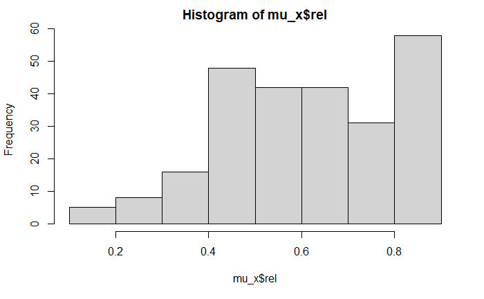

```r
mu_x <- reshape2::melt(mu, id.vars=c("year", "state_ori", "sector_ori"), variable.name="dest", value.name = "rel")
mu_x <- mu_x %>%
  mutate(state_dest = str_split(dest, "_", simplify = T)[, 1]) %>%
  mutate(sector_dest = str_split(dest, "_", simplify = T)[, 2]) %>%
  filter(sector_dest==sector_ori & state_dest==state_ori) %>%
  arrange(rel)
hist(mu_x$rel)
```

```r
NA
NA
NA
```